# Berlin CO2 Leistungsbild

Bhaskar Kamble

15 August 2019

# Teil 2.

```r
source("D:/GITHUB_REPOS/co2emissions/Berlin/BezirkAnalysis/mainScriptCO2Emissions_v2.R")
##
source("D:/GITHUB_REPOS/co2emissions/Berlin/BezirkAnalysis/getCumSums.R")
```

```r
require(ggplot2)
#look at line 187 of BerlinPresentationCO2BalanceUnified_v6.Rmd#
points_line_lm <- function(input_data,
                           xVar,
                           yVar,
                           ymin,
                           ymax,
                           x_eq=2008,
                           y_eq=2500,
                           size_eq=6,
                           plot_title,
                           xlab,
                           ylab,
                           slope_round_to = 2,
                           intercept_round_to = 0) {
  linmod <- lm(data=input_data , formula = get(yVar)~get(xVar))
  coeff_a <- as.numeric(coefficients(linmod)[1])
  coeff_b <- as.numeric(coefficients(linmod)[2])
  if (coeff_a<0) {
    sign_coeff_a <- " "
  } else {sign_coeff_a <- "+"}


  b_round <- as.character(round(coeff_b,slope_round_to))
  a_round <- as.character(round(coeff_a,intercept_round_to))
  lm_equation <- paste0( b_round , "x" , sign_coeff_a ,  a_round)

  g <- ggplot() + geom_line(data=input_data , aes(x=get(xVar) , y=get(yVar)) , color="blue"
  )+geom_point(data=input_data , aes(x=get(xVar) , y=get(yVar)) , color="blue"
  )+geom_smooth(method="lm" , data=input_data , aes(x=get(xVar) , y=get(yVar)) , se=FALSE
  )+annotate(geom="text" , label=lm_equation , x = x_eq , y = y_eq , size=size_eq
  )+ylim(ymin,ymax)+scale_x_continuous(breaks=seq(2002,2018,2)
  )+theme_bw()+labs(x=xlab,
  y=ylab,title=plot_title)+theme(
    plot.title=element_text(size=10),
    axis.title.x=element_text(size=15, face="bold"),
    axis.title.y = element_text(size=15, face="bold"),
    axis.text.x=element_text(size=10,face="bold"),
    axis.text.y=element_text(size=10,face="bold"))
  return(g)
}
```

```r
require(ggplot2)
col_list <- c("royalblue4","orangered1","gray59","orange","blue","olivedrab4")
cols <- c(
          "erdgas"      = "royalblue4",
          "waerme"      = "orangered1",
          "fluessiggas" = "gray59",
          "heizoel"     = "orange",
          "holzpellets" = "blue",
          "strom"       = "olivedrab4"
          )
plot_title <- NULL
order_legend <- rev(c("erdgas","waerme","fluessiggas","heizoel","holzpellets","strom"))
order_labels <- rev(c("Erdgas","Wärme (N+F)","Flüssiggas","Heizöl","Holzpellets","Strom (D+WP)"))
et_list <- c("erdgas","waerme","fluessiggas","heizoel","holzpellets","strom")
plot_byET <- function(obj,xlabel,ylabel,plottitle) {
  ggplot()+geom_line(data=obj,aes(x=abrechnungsjahr,y=get(et_list[1]),color=et_list[1]),size=5
  )+geom_line(data=obj,aes(x=abrechnungsjahr,y=get(et_list[2]),color=et_list[2])
  )+geom_line(data=obj,aes(x=abrechnungsjahr,y=get(et_list[3]),color=et_list[3])
  )+geom_line(data=obj,aes(x=abrechnungsjahr,y=get(et_list[4]),color=et_list[4])
  )+geom_line(data=obj,aes(x=abrechnungsjahr,y=get(et_list[5]),color=et_list[5])
  )+geom_line(data=obj,aes(x=abrechnungsjahr,y=get(et_list[6]),color=et_list[6])
  )+scale_color_manual(labels=order_labels,name=" ",values=cols,breaks=order_legend
  )+geom_ribbon(data=obj,aes(x=abrechnungsjahr,ymin=0,ymax=get(et_list[6])),fill=col_list[6]
  )+geom_ribbon(data=obj,aes(x=abrechnungsjahr,ymin=0,ymax=get(et_list[5])),fill=col_list[5]
  )+geom_ribbon(data=obj,aes(x=abrechnungsjahr,ymin=0,ymax=get(et_list[4])),fill=col_list[4]
  )+geom_ribbon(data=obj,aes(x=abrechnungsjahr,ymin=0,ymax=get(et_list[3])),fill=col_list[3]
  )+geom_ribbon(data=obj,aes(x=abrechnungsjahr,ymin=0,ymax=get(et_list[2])),fill=col_list[2]
  )+geom_ribbon(data=obj,aes(x=abrechnungsjahr,ymin=0,ymax=get(et_list[1])),fill=col_list[1])+theme_bw()+ labs(
    x=xlabel,y=ylabel,title=plottitle
  ) + theme(
    plot.title=element_text(size=10),
    axis.title.x =element_text(size=15,face="bold"),
    axis.title.y =element_text(size=15, face="bold"),
    legend.text = element_text(size=12),
    axis.text.x=element_text(size=10,face="bold"),
    axis.text.y=element_text(size=10,face="bold"),
    legend.key.size=unit(2, "lines")
  )+scale_x_continuous(breaks=seq(2002,2018,2))
}
```

```r
extract_co2_emission <- function(obj_sfh , obj_mfh) {
  co2_SFH <- obj_sfh$co2_emissions
  co2_MFH <- obj_mfh$co2_emissions
  co2_SFH$strom[co2_SFH$abrechnungsjahr < 2010] <- mean(co2_SFH$strom[co2_SFH$abrechnungsjahr >2009])
  co2_MFH$strom[co2_MFH$abrechnungsjahr < 2010] <- mean(co2_MFH$strom[co2_MFH$abrechnungsjahr >2009])
  #recalculate "total" column
  co2_SFH <- getRowSums(co2_SFH[,names(co2_SFH)!="total"] , dropCols = "abrechnungsjahr")
  co2_MFH <- getRowSums(co2_MFH[,names(co2_MFH)!="total"] , dropCols = "abrechnungsjahr")
  #---
  co2_ALL <- co2_SFH + co2_MFH
  co2_ALL$abrechnungsjahr <- 2002:2018
  co2_SFH <- co2_SFH/1e7
  co2_MFH <- co2_MFH/1e7
  co2_ALL <- co2_ALL/1e7
  co2_SFH$abrechnungsjahr <- 2002:2018
  co2_MFH$abrechnungsjahr <- 2002:2018
  co2_ALL$abrechnungsjahr <- 2002:2018

  return_data <- list()
  return_data$SFH <- co2_SFH
  return_data$MFH <- co2_MFH
  return_data$ALL <- co2_ALL
  return(return_data)
}

extract_aes <- function(obj_sfh , obj_mfh) {
  aes_SFH <- obj_sfh$energy_shares_absolute
  aes_MFH <- obj_mfh$energy_shares_absolute
  aes_SFH$strom[aes_SFH$abrechnungsjahr < 2010] <- mean(aes_SFH$strom[aes_SFH$abrechnungsjahr >2009])
  aes_MFH$strom[aes_MFH$abrechnungsjahr < 2010] <- mean(aes_MFH$strom[aes_MFH$abrechnungsjahr >2009])
  aes_SFH <- getRowSums(aes_SFH , dropCols = "abrechnungsjahr")
  aes_MFH <- getRowSums(aes_MFH , dropCols = "abrechnungsjahr")
  aes_ALL <- aes_SFH + aes_MFH
  aes_ALL$abrechnungsjahr <- 2002:2018

  return_data <- list()
  return_data$SFH <- aes_SFH
  return_data$MFH <- aes_MFH
  return_data$ALL <- aes_ALL
  return(return_data)
}
```

```r
bezirk_proper_names  <- c(
  "Charlottenburg-Wilmersdorf",
  "Friedrichshain-Kreuzberg",
  "Lichtenberg",
  "Marzahn-Hellersdorf",
  "Mitte",
  "Neukölln",
  "Pankow"    ,
  "Reinickendorf",
  "Spandau",
  "Steglitz-Zehlendorf" ,
  "Tempelhof-Schöneberg",
  "Treptow-Köpenick"
)

bezirk_list  <- c(
  "charlottenburg_wilmersdorf",
  "friedrichshain_kreuzberg",
  "lichtenberg",
  "marzahn_hellersdorf",
  "mitte",
  "neukoelln",
  "pankow"    ,
  "reinickendorf",
  "spandau",
  "steglitz_zehlendorf" ,
  "tempelhof_schoeneberg",
  "treptow_koepenick"
)
```

```r
i_bezirk <- 0
i_section <- 6
```

```r
i_bezirk           <- i_bezirk + 1
bezirk             <- bezirk_list[i_bezirk]
bezirk_proper_name <- bezirk_proper_names[i_bezirk]
et_list <- c("erdgas","waerme","fluessiggas","heizoel","holzpellets","strom")
```

```r
i_section <- i_section + 1
i_subsection <- 0
i_subsubsection <- 0
```

# Charlottenburg-Wilmersdorf

# 7.Charlottenburg-Wilmersdorf, alle Wohngebäude, CO2-Emission aus Beheizung 2002  2018

```r
i_subsection <- i_subsection + 1
```

## 7.1 Absolute Zahlen

### Stichprobengröße

```r
source("D:/GITHUB_REPOS/co2emissions/Berlin/BezirkAnalysis/getSampleSize.R")
berlin_sample_size <- getSampleSize()
```

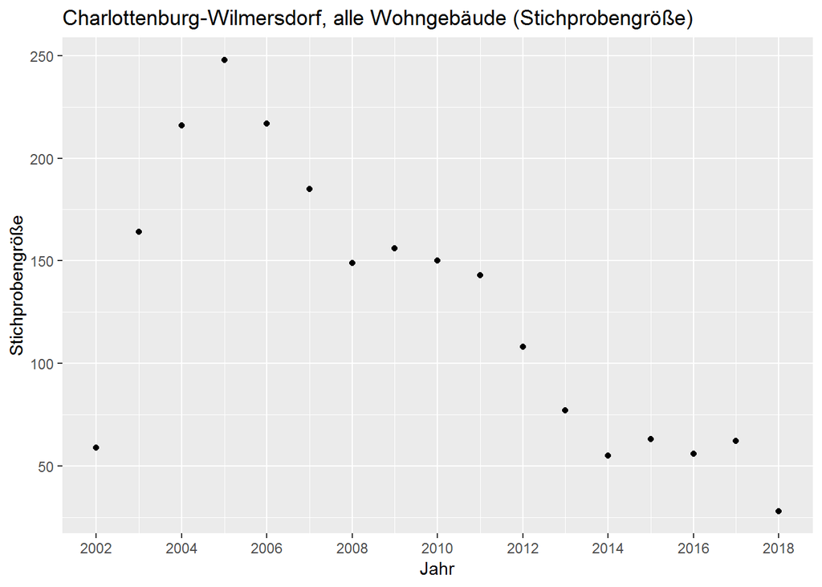

```r
require(ggplot2)
ggplot(berlin_sample_size$ALL) + geom_point(aes(x=abrechnungsjahr,y=get(bezirk)))+labs(x="Jahr",y="Stichprobengröße",title=paste0(bezirk_proper_name , ", alle Wohngebäude (Stichprobengröße)"))+scale_x_continuous(breaks=seq(2002,2018,2))
```

```r
berlin_sample_size$ALL[ , c("abrechnungsjahr",bezirk)]
```

```
##    abrechnungsjahr charlottenburg_wilmersdorf
## 1             2002                         59
## 2             2003                        164
## 3             2004                        216
## 4             2005                        248
## 5             2006                        217
## 6             2007                        185
## 7             2008                        149
## 8             2009                        156
## 9             2010                        150
## 10            2011                        143
## 11            2012                        108
## 12            2013                         77
## 13            2014                         55
## 14            2015                         63
## 15            2016                         56
## 16            2017                         62
## 17            2018                         28
```

```r
source("D:/GITHUB_REPOS/co2emissions/Berlin/BezirkAnalysis/createTable.R")
```

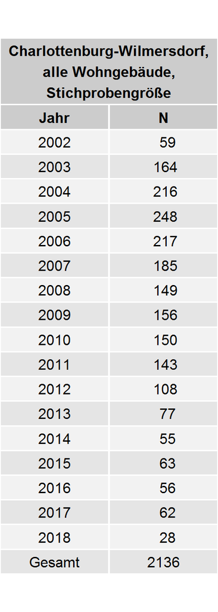

```r
createTable(obj = berlin_sample_size$ALL[,c("abrechnungsjahr",bezirk)],
            fontSize = 10,
            isHeader = TRUE,
            headerName = paste0(bezirk_proper_name,",\nalle Wohngebäude,\nStichprobengröße"),
            columnNames = c("Jahr","N"),
            columnWidths = c(1,1),
            addColTotals = TRUE)
```

```r
i_subsubsection <- i_subsubsection + 1
```

### 7.1.1, alle Wohngebäude, CO2-Emission aus Beheizung 2002 - 2018 in units

```r
return_SFH <- main_function("SFH" , bezirk , et_list)
return_MFH <- main_function("MFH" , bezirk , et_list)
return_co2 <- extract_co2_emission(return_SFH , return_MFH)
```

Here you need just the total co2 emitted, not split by ET.

```r
bezirk_co2_all <- return_co2$ALL
```

```r
changeCO2_to_CO_2 <- function(obj) {
  objBefore <- strsplit(obj,"CO2")[[1]][1]
  objAfter <- strsplit(obj,"CO2")[[1]][2]
  return(bquote(.(objBefore)*CO[2] * .(objAfter)))
}
```

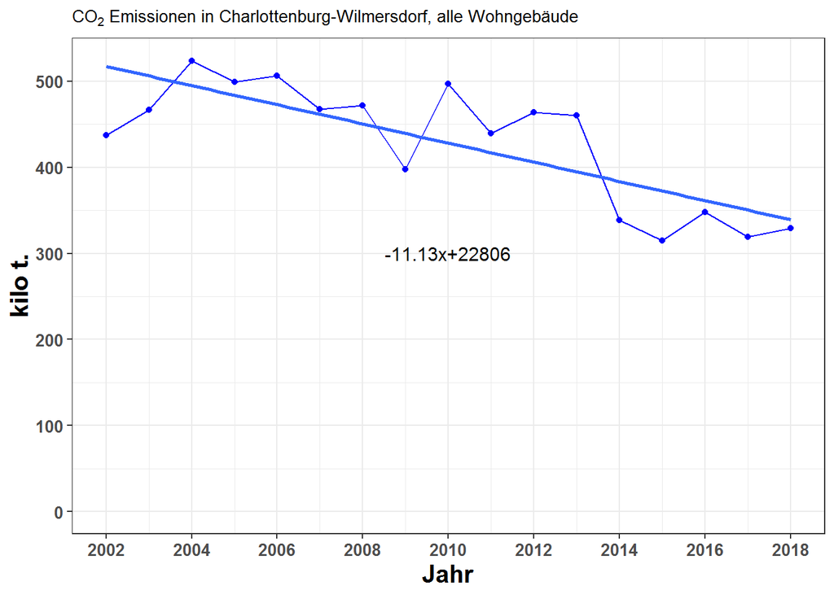

```r
points_line_lm(input_data = bezirk_co2_all,
               xVar = "abrechnungsjahr",
               yVar = "total",
               ymin = 0,
               ymax = max(bezirk_co2_all$total),
               x_eq = 2010,
               y_eq = 300,
               size_eq = 4,
               plot_title = changeCO2_to_CO_2(paste0("CO2 Emissionen in ",bezirk_proper_name, ", alle Wohngebäude")),
               xlab = "Jahr",
               ylab = "kilo t.")
```

```r
bezirk_co2_all[ , c("abrechnungsjahr","total")]
```

```
##    abrechnungsjahr    total
## 1             2002 437.5293
## 2             2003 466.5623
## 3             2004 523.9296
## 4             2005 499.0712
## 5             2006 506.4530
## 6             2007 467.4310
## 7             2008 471.6374
## 8             2009 397.8959
## 9             2010 497.1840
## 10            2011 439.2849
## 11            2012 463.8478
## 12            2013 460.5407
## 13            2014 338.4202
## 14            2015 314.9513
## 15            2016 348.3044
## 16            2017 318.8350
## 17            2018 329.1718
```

```r
createTable(obj = bezirk_co2_all[, c("abrechnungsjahr","total")],
            fontSize = 10,
            isHeader = TRUE,
            headerName = paste0(bezirk_proper_name,"\nalle Wohngebäude\nCO2 Emissionen"),
            columnNames = c("Jahr","kilo t."),
            columnWidths = c(1,1),
            columnsToRound = "kilo t."
)
```

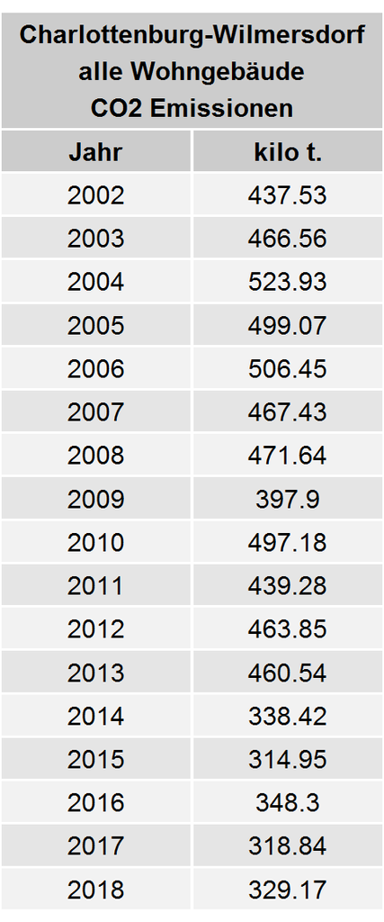

```r
i_subsubsection <- i_subsubsection + 1
```

### 7.1.2, alle Wohngebäude, CO2-Emission aus Beheizung 2002 - 2018 nach Energieträgern, Anteile in units CO2, summiert

Here you need to split by ET

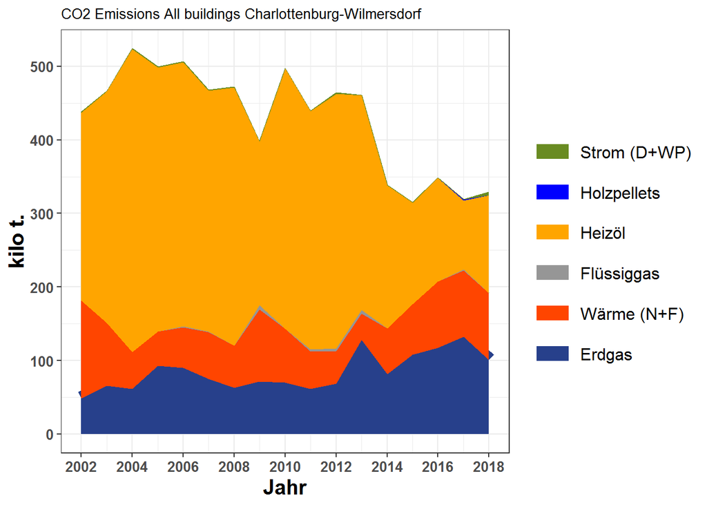

```r
bezirk_co2_all_cumsums <- getCumSums(bezirk_co2_all , dropCols = c("abrechnungsjahr","total"))
plot_byET(bezirk_co2_all_cumsums , xlabel = "Jahr" , ylabel = "kilo t." , plottitle = paste0("CO2 Emissions All buildings ",bezirk_proper_name) )
```

```r
bezirk_co2_all
```

```
##    abrechnungsjahr    erdgas    waerme fluessiggas   heizoel holzpellets
## 1             2002  48.47211 133.26914  0.00000000 255.19325  0.00000000
## 2             2003  65.86176  84.67930  0.00000000 315.42640  0.00000000
## 3             2004  61.71133  49.66962  0.00000000 411.95382  0.00000000
## 4             2005  92.81228  46.35950  0.00000000 359.30460  0.00000000
## 5             2006  90.33988  55.07523  1.01558940 359.42751  0.00000000
## 6             2007  74.80501  64.08687  0.19477001 327.74952  0.00000000
## 7             2008  62.61955  57.13934  0.00000000 351.28368  0.00000000
## 8             2009  71.04196  98.09424  5.88797799 222.27688  0.00000000
## 9             2010  69.87038  72.72262  0.06528461 354.50603  0.01970715
## 10            2011  61.15954  51.30493  2.86124897 323.56947  0.38973451
## 11            2012  68.88118  43.75322  3.69670590 346.64025  0.00000000
## 12            2013 127.94469  35.67391  5.09585046 291.82627  0.00000000
## 13            2014  81.63803  62.03887  0.00000000 194.74329  0.00000000
## 14            2015 107.98517  68.80819  0.00000000 138.15789  0.00000000
```

[output cut: 21 more lines]

```r
createTable(bezirk_co2_all,
            fontSize = 10,
            isHeader = TRUE,
            headerName = paste0(bezirk_proper_name,", alle Wohngebäude, CO2 Emissionen nach Energieträgern (kilo t.)"),
            columnNames =  c("Jahr","Erdgas","Wärme","Flüssiggas","Heizöl","Holzpellets","Strom","Gesamt"),
            columnWidths = rep(1,8),
            columnsToRound = c("Erdgas","Wärme","Flüssiggas","Heizöl","Holzpellets","Strom","Gesamt")
)
```

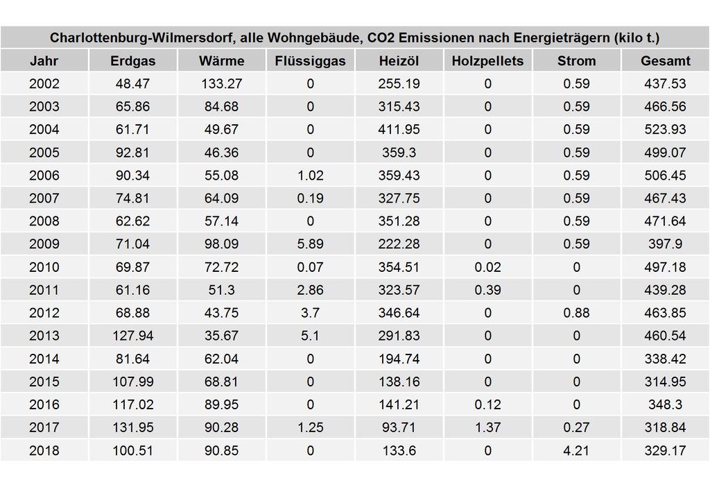

```r
i_subsubsection <- i_subsubsection + 1
```

### 7.1.3, alle Wohngebäude, Emission aus Beheizung 2002 - 2018 nach Energieträgern, Anteile in %

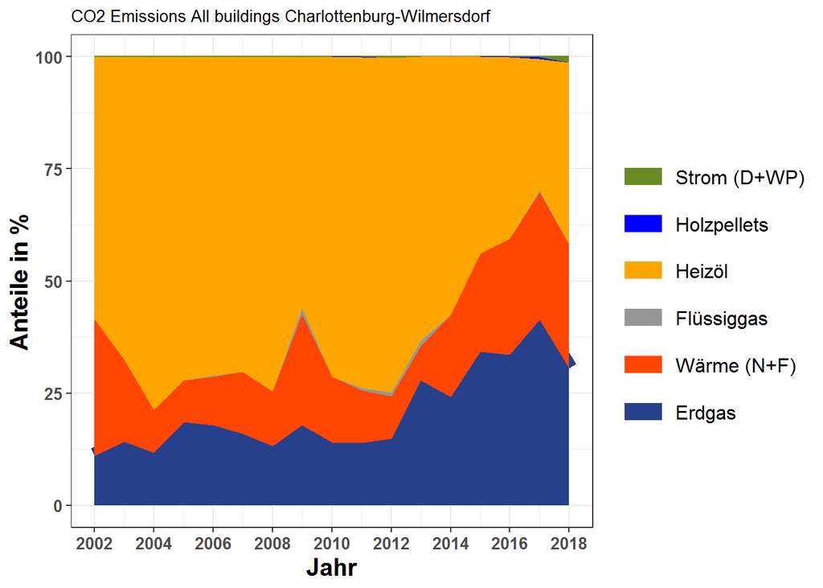

```r
bezirk_co2_all_prop <- find_proportions(bezirk_co2_all,drop_cols = c("abrechnungsjahr","total"))
bezirk_co2_all_prop_cumsums <- getCumSums(bezirk_co2_all_prop,dropCols="abrechnungsjahr")
plot_byET(bezirk_co2_all_prop_cumsums , xlabel = "Jahr" , ylabel = "Anteile in %" , plottitle = paste0("CO2 Emissions All buildings ",bezirk_proper_name) )
```

```r
bezirk_co2_all_prop
```

```
##      erdgas    waerme fluessiggas  heizoel holzpellets      strom
## 1  11.07860 30.459477  0.00000000 58.32598 0.000000000 0.13595039
## 2  14.11639 18.149625  0.00000000 67.60649 0.000000000 0.12749055
## 3  11.77855  9.480208  0.00000000 78.62771 0.000000000 0.11353106
## 4  18.59700  9.289156  0.00000000 71.99466 0.000000000 0.11918596
## 5  17.83776 10.874696  0.20052983 70.96956 0.000000000 0.11744876
## 6  16.00343 13.710445  0.04166819 70.11720 0.000000000 0.12725361
## 7  13.27705 12.115100  0.00000000 74.48173 0.000000000 0.12611867
## 8  17.85441 24.653244  1.47977855 55.86308 0.000000000 0.14949207
## 9  14.05322 14.626902  0.01313087 71.30278 0.003963753 0.00000000
## 10 13.92252 11.679191  0.65134241 73.65822 0.088720212 0.00000000
## 11 14.84995  9.432668  0.79696536 74.73147 0.000000000 0.18894148
## 12 27.78141  7.746093  1.10649294 63.36601 0.000000000 0.00000000
## 13 24.12327 18.331906  0.00000000 57.54482 0.000000000 0.00000000
## 14 34.28631 21.847250  0.00000000 43.86644 0.000000000 0.00000000
```

[output cut: 21 more lines]

```r
createTable(bezirk_co2_all_prop,
            fontSize = 10,
            isHeader = TRUE,
            headerName = paste0(bezirk_proper_name,", alle Wohngebäude, CO2 Emissionen, Anteile nach Energieträgern (%)"),
            columnNames =  c("Erdgas","Wärme","Flüssiggas","Heizöl","Holzpellets","Strom","Jahr"),
            columnWidths = rep(1,7),
            columnsToRound = c("Erdgas","Wärme","Flüssiggas","Heizöl","Holzpellets","Strom")
)
```

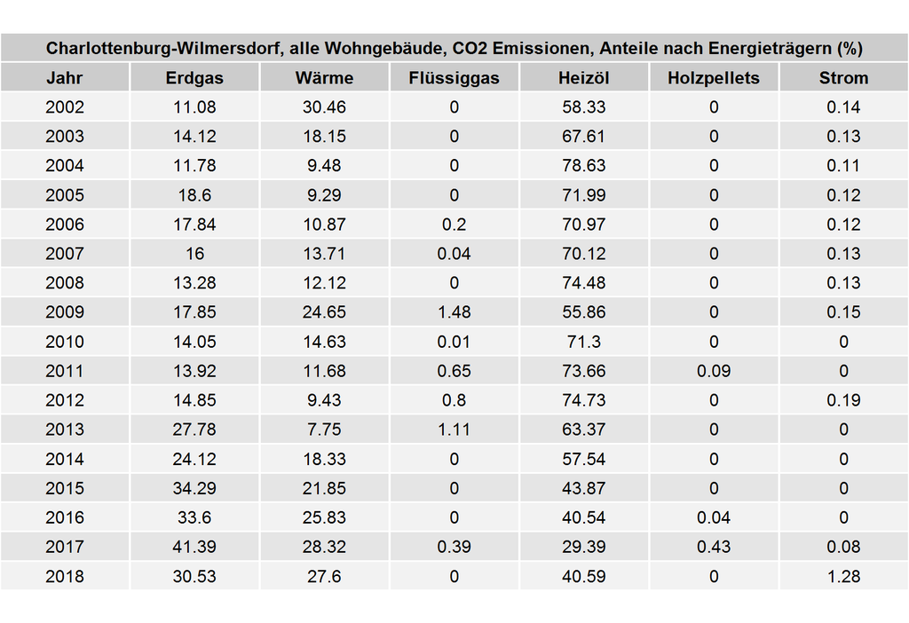

```r
i_subsection <- i_subsection + 1
i_subsubsection <- 0
```

## 7.2. Flächenbezug

```r
i_subsubsection <- i_subsubsection + 1
```

### 7.2.1. alle Wohngebäude, flächenbezogene Emission aus Beheizung 2002 - 2018

```r
bezirk_total_area <- return_SFH$totalArea
bezirk_total_area$areaALL <- bezirk_total_area$areaSFH + bezirk_total_area$areaMFH
bezirk_total_area <- 100*bezirk_total_area
bezirk_total_area$abrechnungsjahr <- 2002:2018
```

```r
bezirk_spzco2_all <- data.frame(abrechnungsjahr=2002:2018 ,   spzco2 = 1e6*(bezirk_co2_all$total / bezirk_total_area$areaALL) )
#bezirk_spzco2_all
```

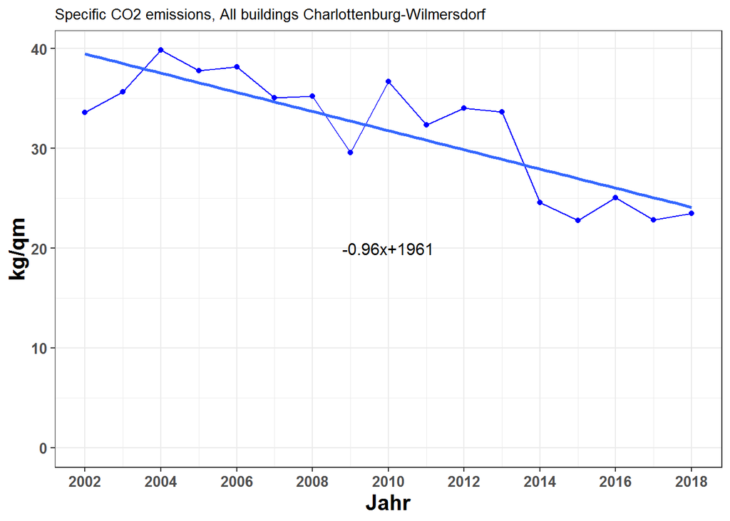

```r
points_line_lm(input_data = bezirk_spzco2_all,
               xVar = "abrechnungsjahr",
               yVar = "spzco2",
               ymin=0,
               ymax=max(bezirk_spzco2_all$spzco2),
               x_eq = 2010,
               y_eq = 20,
               size_eq = 4,
               plot_title = paste0("Specific CO2 emissions, All buildings ",bezirk_proper_name),
               xlab = "Jahr",
               ylab = "kg/qm")
```

```r
bezirk_spzco2_all[, c("abrechnungsjahr","spzco2")]
```

```
##    abrechnungsjahr   spzco2
## 1             2002 33.57633
## 2             2003 35.63707
## 3             2004 39.83281
## 4             2005 37.76728
## 5             2006 38.14932
## 6             2007 35.04844
## 7             2008 35.20240
## 8             2009 29.56346
## 9             2010 36.70257
## 10            2011 32.32556
## 11            2012 34.03863
## 12            2013 33.67363
## 13            2014 24.59735
## 14            2015 22.80240
## 15            2016 25.07753
## 16            2017 22.81435
## 17            2018 23.49628
```

```r
createTable(obj = bezirk_spzco2_all[, c("abrechnungsjahr","spzco2")],
            fontSize = 10,
            isHeader = TRUE,
            headerName = paste0(bezirk_proper_name,"\nalle Wohngebäude\nspezifische CO2 Emissionen"),
            columnNames = c("Jahr","kg / q.m."),
            columnWidths = c(1,1),
            columnsToRound = "kg / q.m."
)
```

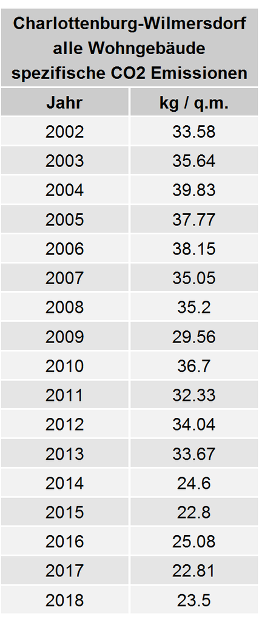

Isn’t it strange that the above graph has almost exactly the same shape as total co2 emissions?

```r
i_subsubsection <- i_subsubsection + 1
```

### 7.2.2. alle Wohngebäude, flächenbezogene CO2-Emssion und beheizte Wohnfläche 2002  2018

```r
#plot(bezirk_total_area$abrechnungsjahr , bezirk_total_area$areaALL)
```

```r
plot_dualPlot <- function(y1 , y2 , x , xlab, ylab1 , ylab2, ylegend1, ylegend2) {
  dframe <- data.frame(x=x , y1=y1 , y2=y2)
 lm1 <- lm(y1~x , data = dframe)
 lm2 <- lm(y2~x , data = dframe)
 #replace with linear predictions
 y1 <- as.numeric(lm1$fitted.values)
 y2 <- as.numeric(lm2$fitted.values)

 par(mar=c(5, 4, 4, 6) + 0.1)
 plot(x,y1,ylim=c(0,max(y1)),col="black",xlab=xlab,ylab=ylab1,pch=16)

 par(new=TRUE)

 plot(x,y2,xlab="", ylab="", ylim=c(0,max(y2)), axes = FALSE , col = "red",pch=15)
 mtext(ylab2, side = 4, line = 4,col="red")
 axis(4, ylim=c(0,max(y2)), col="red",col.axis="red",las=1)

 legend("bottomleft", c(ylegend1, ylegend2),
       col = c("black", "red"), pch = c(16, 15))

}
```

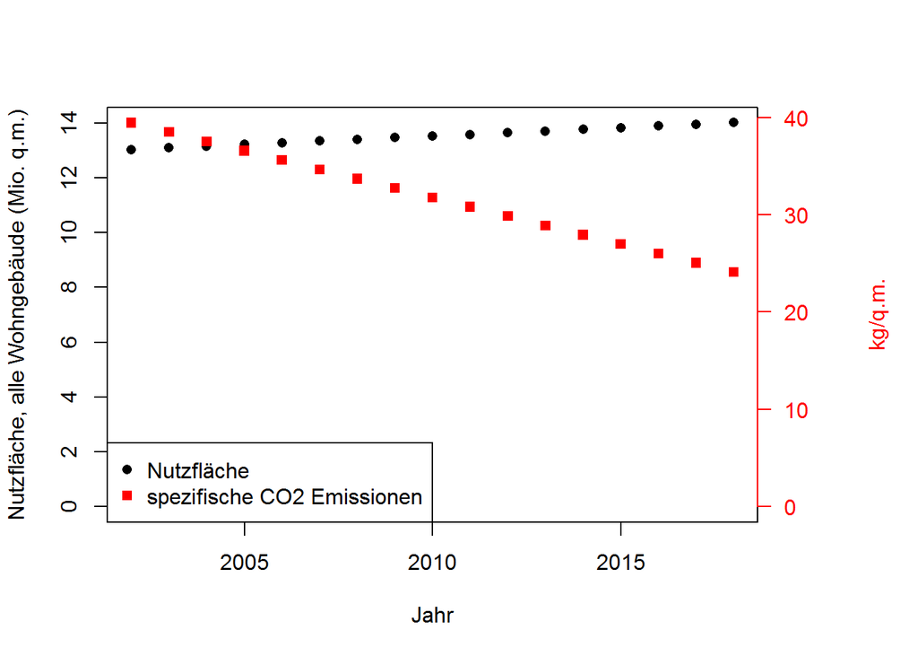

```r
plot_dualPlot(
  1e-6*bezirk_total_area$areaALL,
  bezirk_spzco2_all$spzco2,
  2002:2018,
  "Jahr",
  "Nutzfläche, alle Wohngebäude (Mio. q.m.)",
  "kg/q.m.",
  "Nutzfläche",
  "spezifische CO2 Emissionen")
```

```r
data.frame(Jahr=2002:2018,Area=bezirk_total_area$areaALL,Spez_CO2 = bezirk_spzco2_all$spzco2)
```

```
##    Jahr     Area Spez_CO2
## 1  2002 13030885 33.57633
## 2  2003 13092050 35.63707
## 3  2004 13153215 39.83281
## 4  2005 13214381 37.76728
## 5  2006 13275546 38.14932
## 6  2007 13336712 35.04844
## 7  2008 13397877 35.20240
## 8  2009 13459043 29.56346
## 9  2010 13546300 36.70257
## 10 2011 13589400 32.32556
## 11 2012 13627100 34.03863
## 12 2013 13676600 33.67363
## 13 2014 13758400 24.59735
## 14 2015 13812200 22.80240
## 15 2016 13889100 25.07753
## 16 2017 13975200 22.81435
## 17 2018 14009532 23.49628
```

```r
i_subsection <- i_subsection + 1
i_subsubsection <- 0
```

## 7.3. Emission pro Einwohner

```r
i_subsubsection <- i_subsubsection + 1
```

### 7.3.1. alle Wohngebäude, CO2-Emission aus der Beheizung von Wohnraum pro Einwohner 2002 - 2018

```r
source("D:/GITHUB_REPOS/co2emissions/Berlin/BezirkAnalysis/getBerlinBezirkPopulation.R")
bezirk_population <- getBerlinBezirkPopulation()
bezirk_population[,c("abrechnungsjahr",bezirk)]# and
```

```
##    abrechnungsjahr charlottenburg_wilmersdorf
## 1             2002                     308961
## 2             2003                     308946
## 3             2004                     309041
## 4             2005                     309157
## 5             2006                     309538
## 6             2007                     310281
## 7             2008                     310969
## 8             2009                     312067
## 9             2010                     313912
## 10            2011                     316333
## 11            2012                     319153
## 12            2013                     322778
## 13            2014                     327046
## 14            2015                     330954
## 15            2016                     334646
## 16            2017                     336719
## 17            2018                     338802
```

```r
bezirk_co2_all[,c("abrechnungsjahr","total")]
```

```
##    abrechnungsjahr    total
## 1             2002 437.5293
## 2             2003 466.5623
## 3             2004 523.9296
## 4             2005 499.0712
## 5             2006 506.4530
## 6             2007 467.4310
## 7             2008 471.6374
## 8             2009 397.8959
## 9             2010 497.1840
## 10            2011 439.2849
## 11            2012 463.8478
## 12            2013 460.5407
## 13            2014 338.4202
## 14            2015 314.9513
## 15            2016 348.3044
## 16            2017 318.8350
## 17            2018 329.1718
```

```r
#are the relevant objects here
```

```r
bezirk_prokopf_co2 <- data.frame(abrechnungsjahr=2002:2018 , prokopfco2 = 1e6* bezirk_co2_all$total/bezirk_population[[bezirk]])
#bezirk_prokopf_co2
```

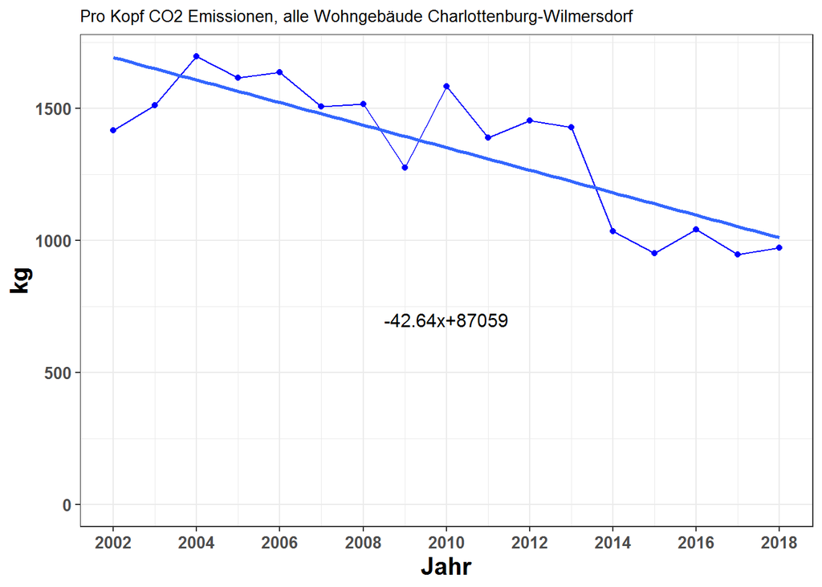

```r
points_line_lm(input_data = bezirk_prokopf_co2,
               xVar = "abrechnungsjahr",
               yVar = "prokopfco2",
               ymin=0,
               ymax=max(bezirk_prokopf_co2$prokopfco2),
               x_eq = 2010,
               y_eq = 700,
               size_eq = 4,
               plot_title = paste0("Pro Kopf CO2 Emissionen, alle Wohngebäude ",bezirk_proper_name),
               xlab = "Jahr",
               ylab = "kg")
```

```r
createTable(obj = bezirk_prokopf_co2,
            isHeader = TRUE,
            headerName = paste0(bezirk_proper_name,"\nalle Wohngebäude\nPro Kopf CO2 Emissionen"),
            columnNames = c("Jahr","kg"),
            columnWidths = c(1,1),
            columnsToRound = "kg"
)
```

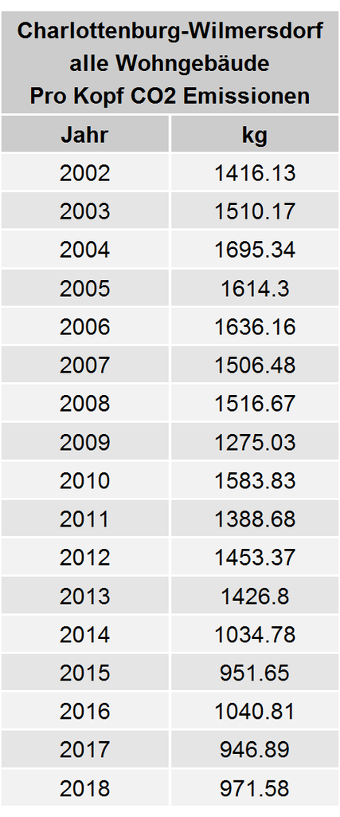

```r
i_subsection <- i_subsection + 1
i_subsubsection <- 0
```

```r
i_subsubsection <- i_subsubsection + 1
```

```r
i_subsection <- i_subsection + 1
i_subsubsection <- 0
```

```r
i_subsubsection <- i_subsubsection + 1
```

```r
i_subsubsection <- i_subsubsection + 1
```

```r
i_subsubsection <- i_subsubsection + 1
```

```r
i_subsubsection <- i_subsubsection + 1
```

```r
i_section <- i_section + 1
i_subsection <- 0
i_subsubsection <- 0
```

# 8.Charlottenburg-Wilmersdorf, 1-2 Familiengebäude, CO2-Emission aus Beheizung 2002  2018

```r
i_subsection <- i_subsection + 1
```

## 8.1 Absolute Zahlen

```r
i_subsubsection <- i_subsubsection + 1
```

### 8.1.1, 1-2 Familiengebäude, CO2-Emission aus Beheizung 2002 - 2018 in units

Here you need just the total co2 emitted, not split by ET.

```r
bezirk_co2_sfh <- return_co2$SFH
```

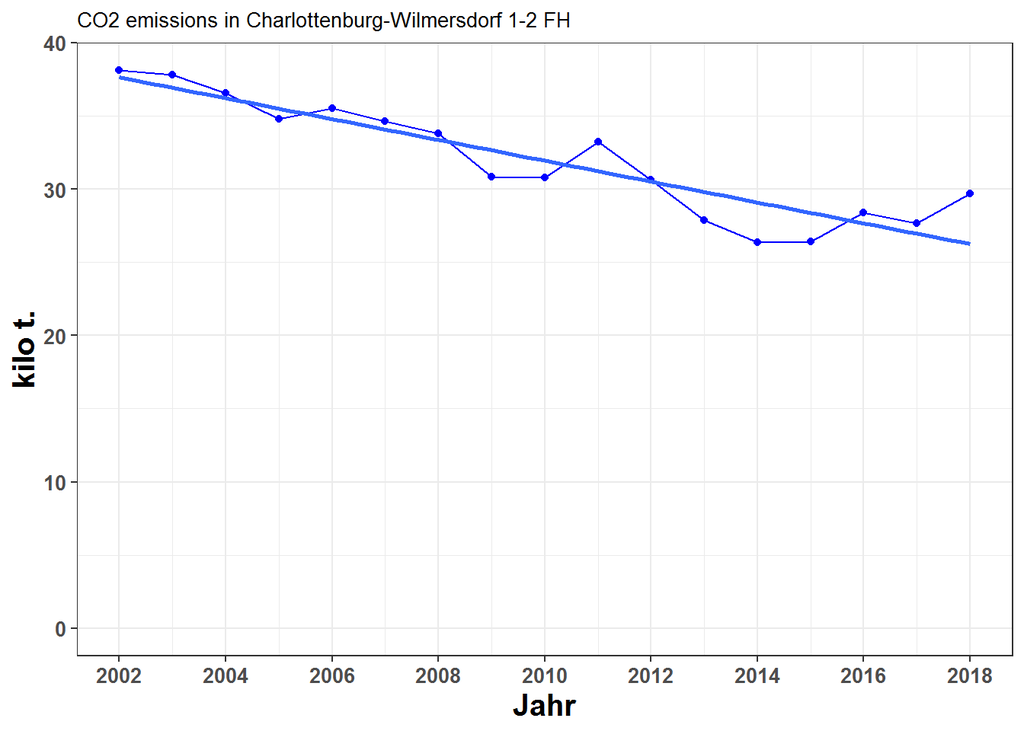

```r
points_line_lm(input_data = bezirk_co2_sfh,
               xVar = "abrechnungsjahr",
               yVar = "total",
               ymin = 0,
               ymax = max(bezirk_co2_sfh$total),
               x_eq = 2010,
               y_eq = 300,
               size_eq = 4,
               plot_title = paste0("CO2 emissions in ",bezirk_proper_name, " 1-2 FH"),
               xlab = "Jahr",
               ylab = "kilo t.")
```

```r
bezirk_co2_sfh[, c("abrechnungsjahr","total")]
```

```
##    abrechnungsjahr    total
## 1             2002 38.09742
## 2             2003 37.80490
## 3             2004 36.55557
## 4             2005 34.80975
## 5             2006 35.52038
## 6             2007 34.61589
## 7             2008 33.81660
## 8             2009 30.81899
## 9             2010 30.76203
## 10            2011 33.24231
## 11            2012 30.61746
## 12            2013 27.84803
## 13            2014 26.35995
## 14            2015 26.40115
## 15            2016 28.38397
## 16            2017 27.63538
## 17            2018 29.68616
```

```r
i_subsubsection <- i_subsubsection + 1
```

### 8.1.2, 1-2 Familiengebäude, CO2-Emission aus Beheizung 2002 - 2018 nach Energieträgern, Anteile in units CO2, summiert

Here you need to split by ET

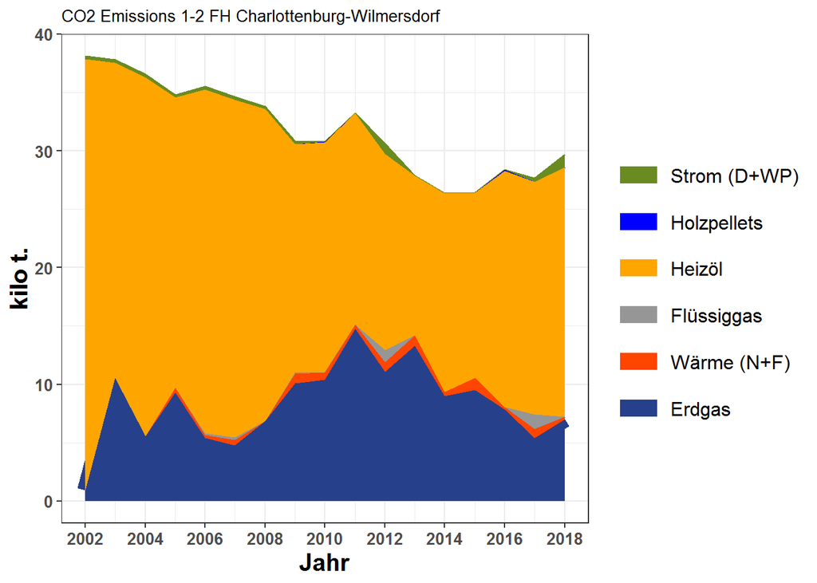

```r
bezirk_co2_sfh_cumsums <- getCumSums(bezirk_co2_sfh , dropCols = c("abrechnungsjahr","total"))
plot_byET(bezirk_co2_sfh_cumsums , xlabel = "Jahr" , ylabel = "kilo t." , plottitle = paste0("CO2 Emissions 1-2 FH ",bezirk_proper_name) )
```

```r
bezirk_co2_sfh
```

```
##    abrechnungsjahr     erdgas    waerme fluessiggas  heizoel holzpellets
## 1             2002  0.9211323 0.0000000  0.00000000 36.92646  0.00000000
## 2             2003 10.5630927 0.0000000  0.00000000 26.99198  0.00000000
## 3             2004  5.5320709 0.0000000  0.00000000 30.77368  0.00000000
## 4             2005  9.3244885 0.3753683  0.00000000 24.86007  0.00000000
## 5             2006  5.4140990 0.2211486  0.19622270 29.43908  0.00000000
## 6             2007  4.7582244 0.4756848  0.19477001 28.93738  0.00000000
## 7             2008  6.8319574 0.0000000  0.00000000 26.73482  0.00000000
## 8             2009 10.0861872 0.8482010  0.08922589 19.54556  0.00000000
## 9             2010 10.3898042 0.6203857  0.06528461 19.66685  0.01970715
## 10            2011 14.7432888 0.3757581  0.00000000 18.12326  0.00000000
## 11            2012 11.0740168 0.8094187  1.04736154 16.81026  0.00000000
## 12            2013 13.3010190 0.9002001  0.00000000 13.64681  0.00000000
## 13            2014  8.9711400 0.3883613  0.00000000 17.00045  0.00000000
## 14            2015  9.5253322 1.0363868  0.00000000 15.83943  0.00000000
```

[output cut: 21 more lines]

```r
i_subsubsection <- i_subsubsection + 1
```

### 8.1.3, 1-2 FH, Emission aus Beheizung 2002 - 2018 nach Energieträgern, Anteile in %

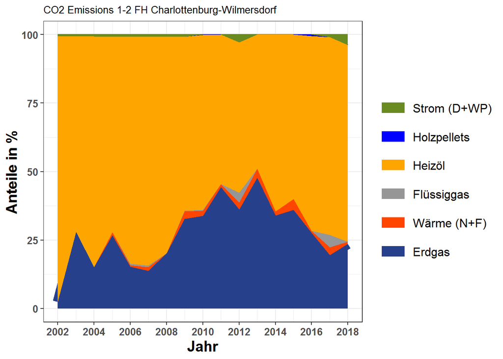

```r
bezirk_co2_sfh_prop <- find_proportions(bezirk_co2_sfh,drop_cols = c("abrechnungsjahr","total"))
bezirk_co2_sfh_prop_cumsums <- getCumSums(bezirk_co2_sfh_prop,dropCols="abrechnungsjahr")
plot_byET(bezirk_co2_sfh_prop_cumsums , xlabel = "Jahr" , ylabel = "Anteile in %" , plottitle = paste0("CO2 Emissions 1-2 FH ",bezirk_proper_name) )
```

```r
bezirk_co2_sfh_prop
```

```
##       erdgas    waerme fluessiggas  heizoel holzpellets     strom
## 1   2.417834 0.0000000   0.0000000 96.92641  0.00000000 0.6557544
## 2  27.941067 0.0000000   0.0000000 71.39810  0.00000000 0.6608284
## 3  15.133317 0.0000000   0.0000000 84.18327  0.00000000 0.6834129
## 4  26.787003 1.0783426   0.0000000 71.41697  0.00000000 0.7176884
## 5  15.242232 0.6225963   0.5524228 82.87942  0.00000000 0.7033301
## 6  13.745783 1.3741808   0.5626608 83.59567  0.00000000 0.7217077
## 7  20.202968 0.0000000   0.0000000 79.05827  0.00000000 0.7387659
## 8  32.727178 2.7522020   0.2895159 63.42048  0.00000000 0.8106219
## 9  33.774765 2.0167252   0.2122246 63.93222  0.06406321 0.0000000
## 10 44.350978 1.1303611   0.0000000 54.51866  0.00000000 0.0000000
## 11 36.168961 2.6436509   3.4207984 54.90417  0.00000000 2.8624217
## 12 47.762872 3.2325450   0.0000000 49.00458  0.00000000 0.0000000
## 13 34.033225 1.4733008   0.0000000 64.49347  0.00000000 0.0000000
## 14 36.079237 3.9255370   0.0000000 59.99523  0.00000000 0.0000000
```

[output cut: 21 more lines]

```r
i_subsection <- i_subsection + 1
i_subsubsection <- 0
```

## 8.2. Flächenbezug

```r
i_subsubsection <- i_subsubsection + 1
```

### 8.2.1. 1-2 FH, flächenbezogene Emission aus Beheizung 2002 - 2018

```r
bezirk_spzco2_sfh <- data.frame(abrechnungsjahr=2002:2018 ,   spzco2 = 1e6*(bezirk_co2_sfh$total / bezirk_total_area$areaSFH) )
#bezirk_spzco2_sfh
```

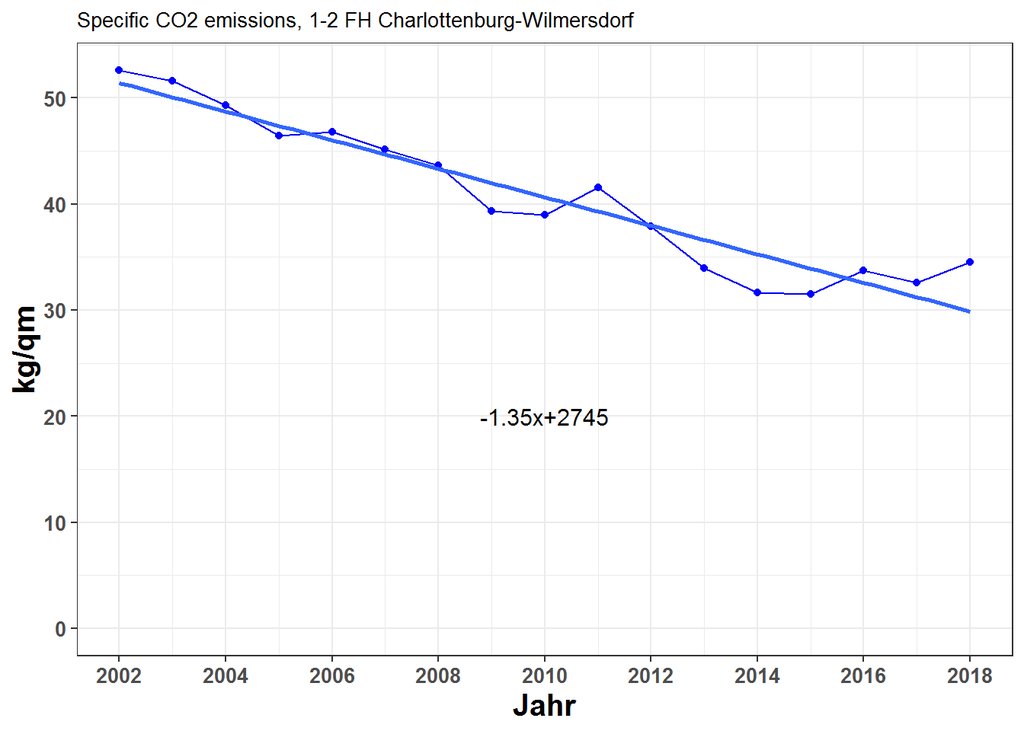

```r
points_line_lm(input_data = bezirk_spzco2_sfh,
               xVar = "abrechnungsjahr",
               yVar = "spzco2",
               ymin=0,
               ymax=max(bezirk_spzco2_sfh$spzco2),
               x_eq = 2010,
               y_eq = 20,
               size_eq = 4,
               plot_title = paste0("Specific CO2 emissions, 1-2 FH ",bezirk_proper_name),
               xlab = "Jahr",
               ylab = "kg/qm")
```

```r
bezirk_spzco2_sfh
```

```
##    abrechnungsjahr   spzco2
## 1             2002 52.58175
## 2             2003 51.57206
## 3             2004 49.29530
## 4             2005 46.40828
## 5             2006 46.82426
## 6             2007 45.12551
## 7             2008 43.59970
## 8             2009 39.30350
## 9             2010 38.95901
## 10            2011 41.52693
## 11            2012 37.91166
## 12            2013 33.94032
## 13            2014 31.61044
## 14            2015 31.47490
## 15            2016 33.74224
## 16            2017 32.61197
## 17            2018 34.48886
```

Isn’t it strange that the above graph has almost exactly the same shape as total co2 emissions?

```r
i_subsubsection <- i_subsubsection + 1
```

### 8.2.2. 1-2 FH, flächenbezogene CO2-Emssion und beheizte Wohnfläche 2002  2018

```r
#plot(bezirk_total_area$abrechnungsjahr , bezirk_total_area$areaSFH)
```

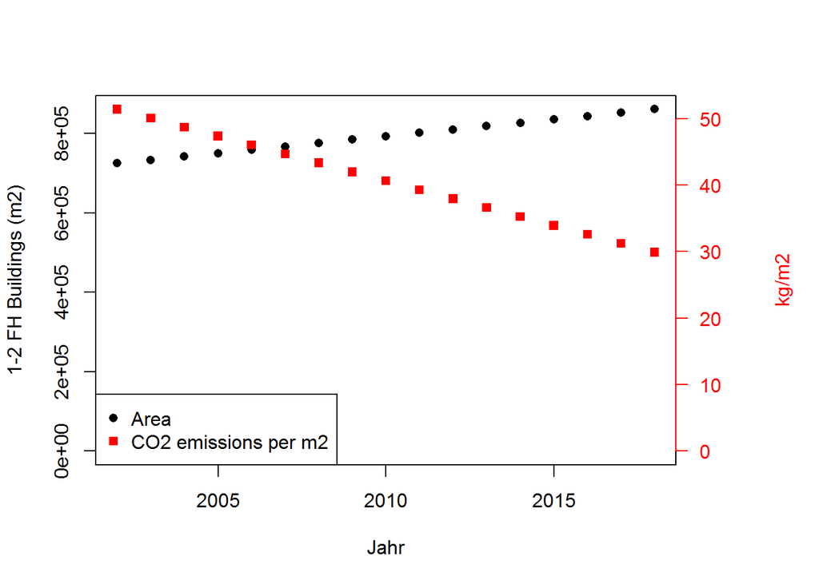

```r
plot_dualPlot(
  bezirk_total_area$areaSFH,
  bezirk_spzco2_sfh$spzco2,
  2002:2018,
  "Jahr",
  "1-2 FH Buildings (m2)",
  "kg/m2",
  "Area",
  "CO2 emissions per m2")
```

```r
data.frame(Jahr=2002:2018,Area=bezirk_total_area$areaSFH,Spez_CO2 = bezirk_spzco2_sfh$spzco2)
```

```
##    Jahr     Area Spez_CO2
## 1  2002 724536.9 52.58175
## 2  2003 733050.0 51.57206
## 3  2004 741563.1 49.29530
## 4  2005 750076.2 46.40828
## 5  2006 758589.3 46.82426
## 6  2007 767102.4 45.12551
## 7  2008 775615.5 43.59970
## 8  2009 784128.6 39.30350
## 9  2010 789600.0 38.95901
## 10 2011 800500.0 41.52693
## 11 2012 807600.0 37.91166
## 12 2013 820500.0 33.94032
## 13 2014 833900.0 31.61044
## 14 2015 838800.0 31.47490
## 15 2016 841200.0 33.74224
## 16 2017 847400.0 32.61197
## 17 2018 860746.4 34.48886
```

```r
i_subsection <- i_subsection + 1
i_subsubsection <- 0
```

## 8.3. Emission pro Einwohner

```r
i_subsubsection <- i_subsubsection + 1
```

### 8.3.1. 1-2 FH, CO2-Emission aus der Beheizung von Wohnraum pro Einwohner 2002 - 2018

- Need data for this.

```r
i_subsection <- i_subsection + 1
i_subsubsection <- 0
```

## 8.4. Prognose

```r
i_subsubsection <- i_subsubsection + 1
```

### 8.4.1. Prognose der CO2-Emission aus Behei¬zung von 1-2 Familiengebäuden 2019 - 2030 in Mio. t (Trend Polynom 2. Grades)

```r
i_subsection <- i_subsection + 1
i_subsubsection <- 0
```

## 8.5. Einflussfaktoren

```r
i_subsubsection <- i_subsubsection + 1
```

### 8.5.1. 1-2 FH, Einfluss der Änderung der beheizten Flächen, des flächenbezogenen Heizenergieverbrauchs, des Energieträgerwechsels und der Dekarbonisierung auf die CO2-Emission

```r
i_subsubsection <- i_subsubsection + 1
```

### 8.5.2. 1-2 FH, Veränderung der flächenbezogenen CO2-Emission aus Beheizung zwischen 2012 und 2018

```r
i_subsubsection <- i_subsubsection + 1
```

### 8.5.3. 1-2 FH, Emissionsintensität der Beheizung von Wohnraum 2002  2018 in kg CO2 - Emission je kWh Heizenergieverbrauch

```r
i_subsubsection <- i_subsubsection + 1
```

### 8.5.4. 1-2 FH, CO2-Emission neu errichteter Gebäude, Vergleich der Baujahre 1990  2001 (WSchV) und 2002  2018 (EnEV)

```r
i_section <- i_section + 1
i_subsection <- 0
i_subsubsection <- 0
```

# 9.Charlottenburg-Wilmersdorf, Mehrfamiliengebäude, CO2-Emission aus Beheizung 2002  2018

```r
i_subsection <- i_subsection + 1
```

## 9.1 Absolute Zahlen

```r
i_subsubsection <- i_subsubsection + 1
```

### 9.1.1, Mehrfamiliengebäude, CO2-Emission aus Beheizung 2002 - 2018 in units

Here you need just the total co2 emitted, not split by ET.

```r
bezirk_co2_mfh <- return_co2$MFH
```

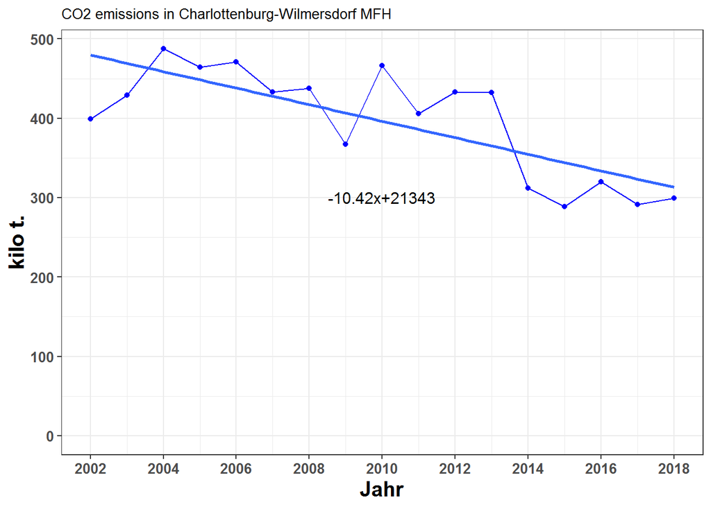

```r
points_line_lm(input_data = bezirk_co2_mfh,
               xVar = "abrechnungsjahr",
               yVar = "total",
               ymin = 0,
               ymax = max(bezirk_co2_mfh$total),
               x_eq = 2010,
               y_eq = 300,
               size_eq = 4,
               plot_title = paste0("CO2 emissions in ",bezirk_proper_name, " MFH"),
               xlab = "Jahr",
               ylab = "kilo t.")
```

```r
i_subsubsection <- i_subsubsection + 1
```

### 9.1.2, Mehrfamiliengebäude, CO2-Emission aus Beheizung 2002 - 2018 nach Energieträgern, Anteile in units CO2, summiert

Here you need to split by ET

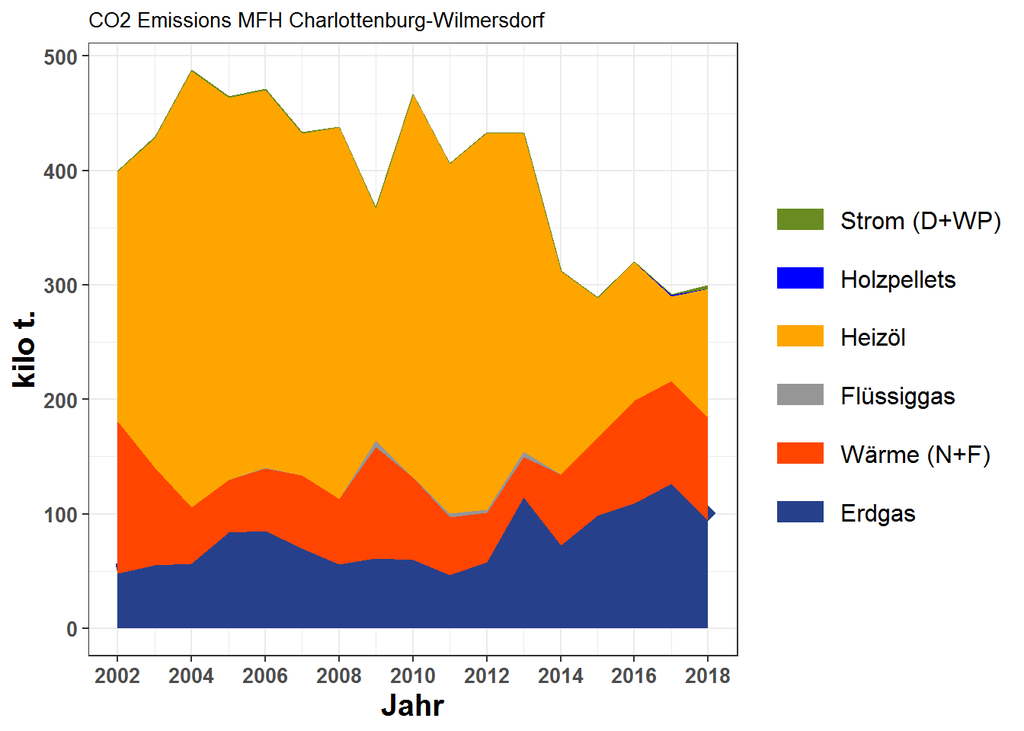

```r
bezirk_co2_mfh_cumsums <- getCumSums(bezirk_co2_mfh , dropCols = c("abrechnungsjahr","total"))
plot_byET(bezirk_co2_mfh_cumsums , xlabel = "Jahr" , ylabel = "kilo t." , plottitle = paste0("CO2 Emissions MFH ",bezirk_proper_name) )
```

```r
i_subsubsection <- i_subsubsection + 1
```

### 9.1.3, MFH, Emission aus Beheizung 2002 - 2018 nach Energieträgern, Anteile in %

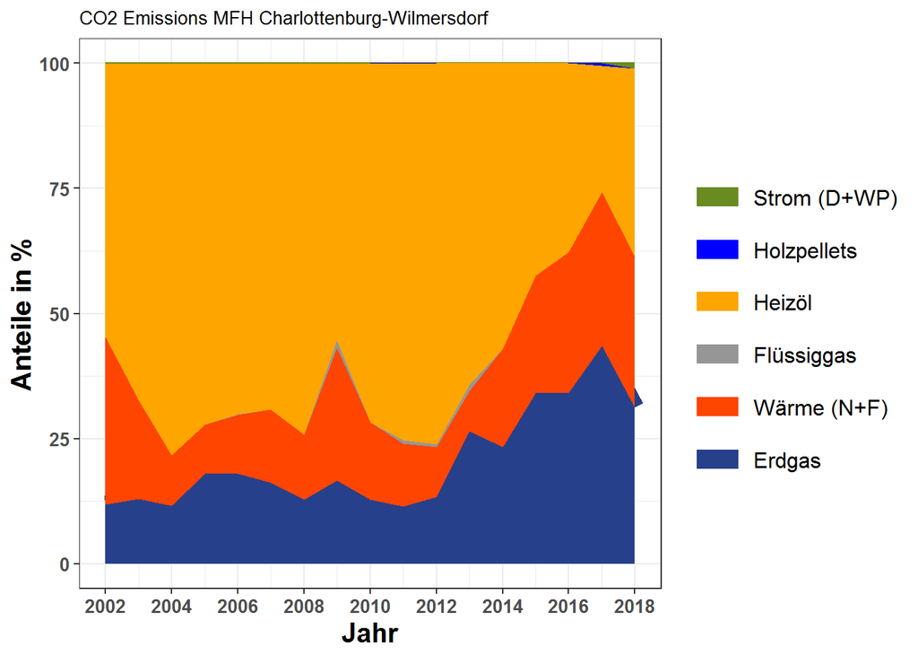

```r
bezirk_co2_mfh_prop <- find_proportions(bezirk_co2_mfh,drop_cols = c("abrechnungsjahr","total"))
bezirk_co2_mfh_prop_cumsums <- getCumSums(bezirk_co2_mfh_prop,dropCols="abrechnungsjahr")
plot_byET(bezirk_co2_mfh_prop_cumsums , xlabel = "Jahr" , ylabel = "Anteile in %" , plottitle = paste0("CO2 Emissions MFH ",bezirk_proper_name) )
```

```r
i_subsection <- i_subsection + 1
i_subsubsection <- 0
```

## 9.2. Flächenbezug

```r
i_subsubsection <- i_subsubsection + 1
```

### 9.2.1. MFH, flächenbezogene Emission aus Beheizung 2002 - 2018

```r
bezirk_spzco2_mfh <- data.frame(abrechnungsjahr=2002:2018 ,   spzco2 = 1e6*(bezirk_co2_mfh$total / bezirk_total_area$areaMFH) )
bezirk_spzco2_mfh
```

```
##    abrechnungsjahr   spzco2
## 1             2002 32.45739
## 2             2003 34.69192
## 3             2004 39.26746
## 4             2005 37.24728
## 5             2006 37.62357
## 6             2007 34.43346
## 7             2008 34.68640
## 8             2009 28.96090
## 9             2010 36.56290
## 10            2011 31.74961
## 11            2012 33.79463
## 12            2013 33.65661
## 13            2014 24.14486
## 14            2015 22.24167
## 15            2016 24.51892
## 16            2017 22.18191
## 17            2018 22.77668
```

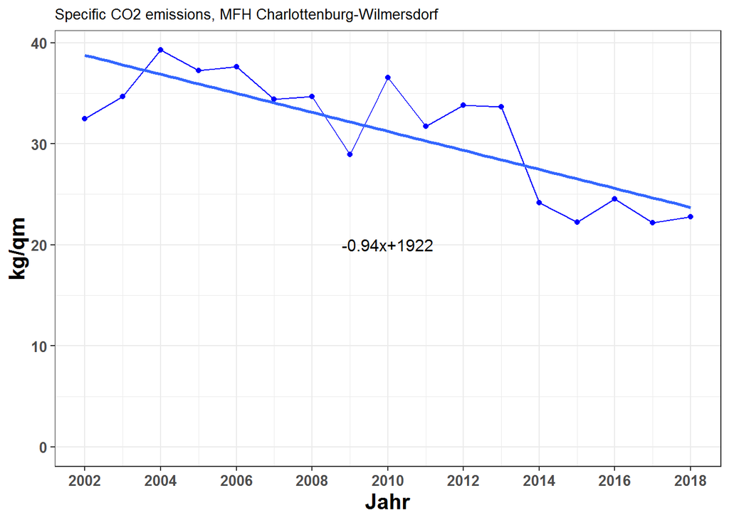

```r
points_line_lm(input_data = bezirk_spzco2_mfh,
               xVar = "abrechnungsjahr",
               yVar = "spzco2",
               ymin=0,
               ymax=max(bezirk_spzco2_mfh$spzco2),
               x_eq = 2010,
               y_eq = 20,
               size_eq = 4,
               plot_title = paste0("Specific CO2 emissions, MFH ",bezirk_proper_name),
               xlab = "Jahr",
               ylab = "kg/qm")
```

```r
i_subsubsection <- i_subsubsection + 1
```

### 9.2.2. MFH, flächenbezogene CO2-Emssion und beheizte Wohnfläche 2002  2018

```r
#plot(bezirk_total_area$abrechnungsjahr , bezirk_total_area$areaMFH)
```

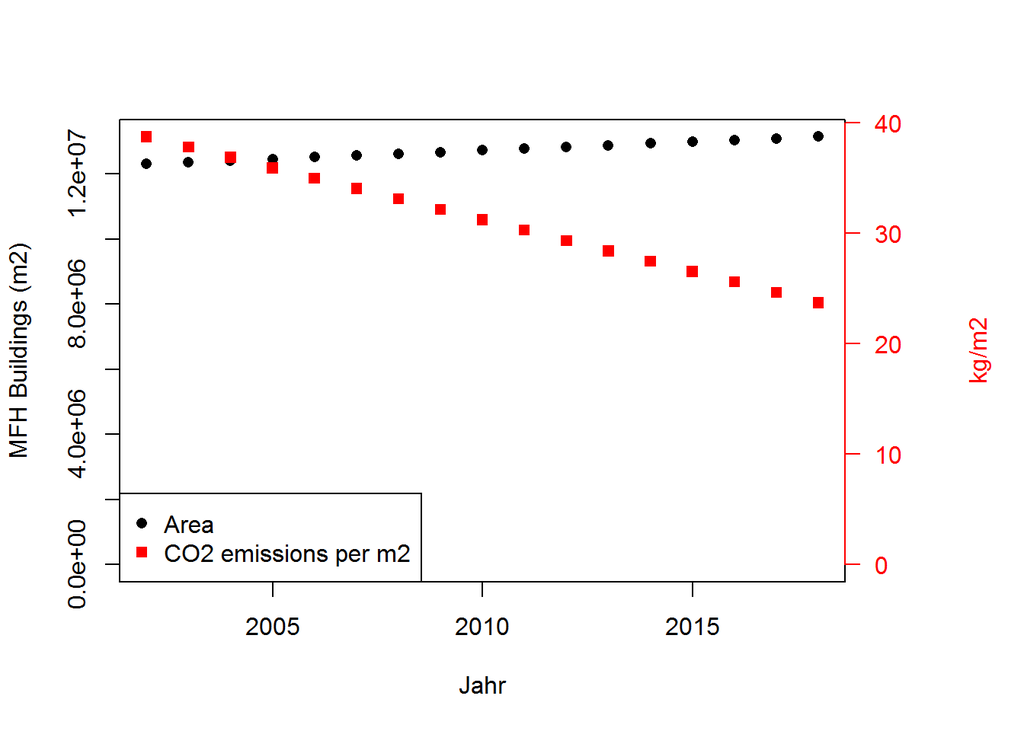

```r
plot_dualPlot(
  bezirk_total_area$areaMFH,
  bezirk_spzco2_mfh$spzco2,
  2002:2018,
  "Jahr",
  "MFH Buildings (m2)",
  "kg/m2",
  "Area",
  "CO2 emissions per m2")
```

```r
i_subsection <- i_subsection + 1
i_subsubsection <- 0
```

## 9.3. Emission pro Einwohner

```r
i_subsubsection <- i_subsubsection + 1
```

### 9.3.1. MFH, CO2-Emission aus der Beheizung von Wohnraum pro Einwohner 2002 - 2018

- Need data for this.

```r
i_subsection <- i_subsection + 1
i_subsubsection <- 0
```

## 9.4. Prognose

```r
i_subsubsection <- i_subsubsection + 1
```

### 9.4.1. Prognose der CO2-Emission aus Behei¬zung von Mehrfamiliengebäuden 2019 - 2030 in Mio. t (Trend Polynom 2. Grades)

```r
i_subsection <- i_subsection + 1
i_subsubsection <- 0
```

## 9.5. Einflussfaktoren

```r
i_subsubsection <- i_subsubsection + 1
```

### 9.5.1. MFH, Einfluss der Änderung der beheizten Flächen, des flächenbezogenen Heizenergieverbrauchs, des Energieträgerwechsels und der Dekarbonisierung auf die CO2-Emission

```r
i_subsubsection <- i_subsubsection + 1
```

### 9.5.2. MFH, Veränderung der flächenbezogenen CO2-Emission aus Beheizung zwischen 2012 und 2018

```r
i_subsubsection <- i_subsubsection + 1
```

### 9.5.3. MFH, Emissionsintensität der Beheizung von Wohnraum 2002  2018 in kg CO2 - Emission je kWh Heizenergieverbrauch

```r
i_subsubsection <- i_subsubsection + 1
```

### 9.5.4. MFH, CO2-Emission neu errichteter Gebäude, Vergleich der Baujahre 1990  2001 (WSchV) und 2002  2018 (EnEV)

```r
i_section <- i_section + 1
i_subsection <- 0
i_subsubsection <- 0
```

# 10.Charlottenburg-Wilmersdorf alle Wohngebäude, Heizenergieverbrauch 2002  2018

```r
i_subsection <- i_subsection + 1
```

## 10.1. alle Wohngebäude, Heizenergieverbrauch 2002 - 2018 in TWh

```r
return_aes <- extract_aes(return_SFH , return_MFH)
bezirk_aes_all <- return_aes$ALL
by_ten_9 <- 1e-9
bezirk_aes_all_TWh <- by_ten_9 * bezirk_aes_all
bezirk_aes_all_TWh$abrechnungsjahr <- 2002:2018
```

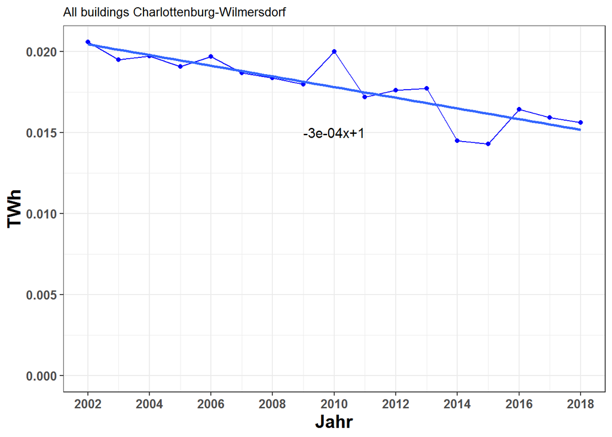

```r
points_line_lm(input_data = bezirk_aes_all_TWh,
               xVar = "abrechnungsjahr",
               yVar = "total",
               ymin=0,
               ymax=max(bezirk_aes_all_TWh$total),
               x_eq = 2010,
               y_eq = 0.015,
               size_eq = 4,
               plot_title = paste0("All buildings ",bezirk_proper_name),
               xlab = "Jahr",
               ylab = "TWh",
               slope_round_to = 4)
```

```r
i_subsection <- i_subsection + 1
```

## 10.2. alle Wohngebäude, Heizenergieverbrauch 2002 - 2018 nach Energieträgern, Anteile in TWh

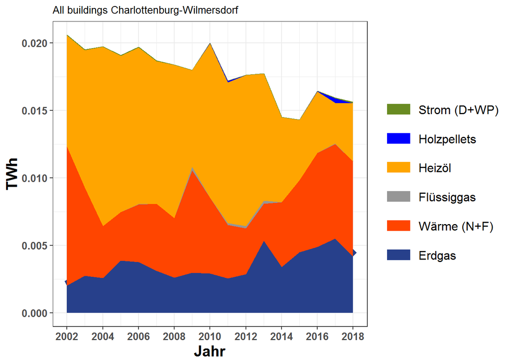

```r
bezirk_aes_all_TWh_cumsums <- getCumSums(bezirk_aes_all_TWh , dropCols = c("abrechnungsjahr","total"))
plot_byET(bezirk_aes_all_TWh_cumsums , xlabel = "Jahr" , ylabel = "TWh" , plottitle = paste0("All buildings ",bezirk_proper_name) )
```

```r
i_subsection <- i_subsection + 1
```

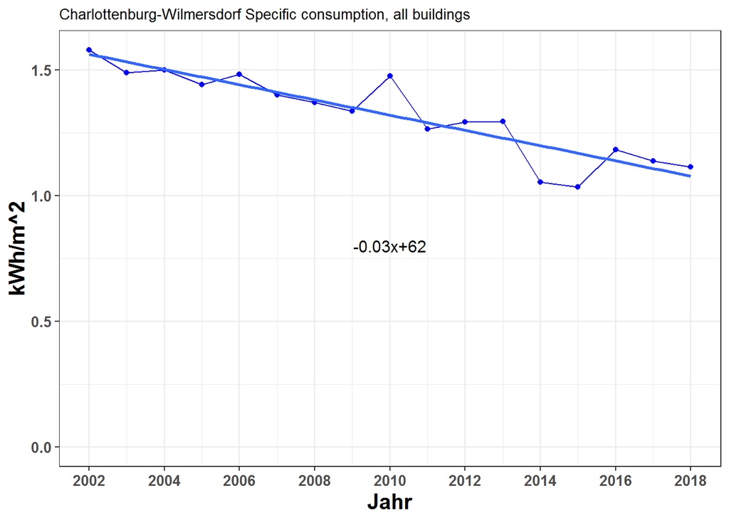

```r
bezirk_spz_verbrauch_all <- data.frame(abrechnungsjahr=2002:2018 ,   kWh_per_m2 =  bezirk_aes_all$total / bezirk_total_area$areaALL)

points_line_lm(input_data = bezirk_spz_verbrauch_all,
               xVar = "abrechnungsjahr",
               yVar = "kWh_per_m2",
               ymin = 0,
               ymax = max(bezirk_spz_verbrauch_all$kWh_per_m2),
               x_eq = 2010,
               y_eq = 0.8,
               size_eq = 4,
               plot_title = paste0(bezirk_proper_name, " Specific consumption, all buildings"),
               xlab = "Jahr",
               ylab = "kWh/m^2")
```

```r
i_subsection <- i_subsection + 1
```

## 10.4. alle Wohngebäude, flächenbezogener Heizenergieverbrauch nach Energieträgern 2002 - 2018 in TWh - **Should this not be TWh/m2** ?

```r
#return_SFH$area_prop_table
#multiply above with total areas to get areas heated by the respective ET
#divide absolute energy share of that ET with above to get the specific energy consumption of that ET
#bezirk_total_area contains the area
#return_aes$ALL contains the energy consumption, which is the same as bezirk_aes_all (in kWh) or bezirk_aes_all_TWh (in TWh).
```

```r
replaceZeroByMean <- function(obj,dropCols) {
  vars <- names(obj)[!(names(obj) %in% dropCols)]
  for (var in vars) {
    isZero <- obj[[var]] == 0
    obj[[var]][isZero] <- mean(obj[[var]][!isZero])
  }
  return(obj)
}

getSpzVrbrchByET <- function(gtype,bezirk_aes,bezirk_total_area,area_prop_table_SFH,area_prop_table_MFH) {
  # gtype is "ALL", "SFH", or "MFH".
  # bezirk_aes is bezirk_aes_all, or bezirk_aes_sfh or bezirk_aes_mfh.
  # bezirk_total_area is bezirk_total_area.
  # area_prop_table_SFH is return_SFH$area_prop_table
  # area_prop_table_MFH is return_MFH$area_prop_table
  #
  # replace zero values by avg in bezirk_aes
  bezirk_aes <- replaceZeroByMean(bezirk_aes,"abrechnungsjahr")

  areas_SFH_byET <- 0.01*bezirk_total_area$areaSFH * area_prop_table_SFH
  areas_SFH_byET$abrechnungsjahr <- 2002:2018
  areas_SFH_byET <- getRowSums(areas_SFH_byET , dropCols = "abrechnungsjahr")

  areas_MFH_byET <- 0.01*bezirk_total_area$areaMFH * area_prop_table_MFH
  areas_MFH_byET$abrechnungsjahr <- 2002:2018
  areas_MFH_byET <- getRowSums(areas_MFH_byET , dropCols = "abrechnungsjahr")

  if (gtype=="ALL") {

    return_data <- list()

    areas_ALL_byET <- areas_SFH_byET + areas_MFH_byET
    areas_ALL_byET$abrechnungsjahr <- 2002:2018

    # replace zero values by avg in areas_ALL_byET
    areas_ALL_byET <- replaceZeroByMean(areas_ALL_byET , "abrechnungsjahr")

    spz_vrbrch_all_byET <- bezirk_aes / areas_ALL_byET
    spz_vrbrch_all_byET$abrechnungsjahr <- 2002:2018

    return_data$aes <- bezirk_aes
    return_data$areas <- areas_ALL_byET
    return_data$spzVrbch <- spz_vrbrch_all_byET
  }

  if (gtype=="SFH") {
    return_data <- list()
    # replace zero values by avg in areas_SFH_byET
    areas_SFH_byET <- replaceZeroByMean(areas_SFH_byET , "abrechnungsjahr")
    spz_vrbrch_sfh_byET <- bezirk_aes / areas_SFH_byET
    spz_vrbrch_sfh_byET$abrechnungsjahr <- 2002:2018
    #return_data <- spz_vrbrch_sfh_byET
    return_data$aes <- bezirk_aes
    return_data$areas <- areas_SFH_byET
    return_data$spzVrbch <- spz_vrbrch_sfh_byET
  }

  if (gtype=="MFH") {
    return_data <- list()
    # replace zero values by avg in areas_MFH_byET
    areas_MFH_byET <- replaceZeroByMean(areas_MFH_byET , "abrechnungsjahr")
    spz_vrbrch_mfh_byET <- bezirk_aes / areas_MFH_byET
    spz_vrbrch_mfh_byET$abrechnungsjahr <- 2002:2018
    #return_data <- spz_vrbrch_mfh_byET
    return_data$aes <- bezirk_aes
    return_data$areas <- areas_MFH_byET
    return_data$spzVrbch <- spz_vrbrch_mfh_byET
  }
  return(return_data)
}
```

```r
SV_all_byET <- getSpzVrbrchByET("ALL",
                                        bezirk_aes_all,
                                        bezirk_total_area,
                                        return_SFH$area_prop_table,
                                        return_MFH$area_prop_table)
spz_vrbrch_all_byET <- SV_all_byET$spzVrbch
#spz_vrbrch_all_byET
```

```r
y_max <- 2.15
g_erdgas <- points_line_lm(input_data = spz_vrbrch_all_byET,
                           xVar = "abrechnungsjahr",
                           yVar = "erdgas",
                           ymin=0,
                           ymax=y_max,
                           x_eq = 2010,
                           y_eq = 1.0,
                           size_eq = 4,
                           plot_title = paste0("Specific Energy Consumption, ALL, ",bezirk_proper_name," erdgas"),
                           xlab = "Jahr",
                           ylab = "kWh/qm")
g_waerme <- points_line_lm(input_data = spz_vrbrch_all_byET,
                           xVar = "abrechnungsjahr",
                           yVar = "waerme",
                           ymin=0,
                           ymax=y_max,
                           x_eq = 2010,
                           y_eq = 1.0,
                           size_eq = 4,
                           plot_title = paste0("Specific Energy Consumption, ALL, ",bezirk_proper_name," waerme"),
                           xlab = "Jahr",
                           ylab = "kWh/qm")
g_fluessiggas <- points_line_lm(input_data = spz_vrbrch_all_byET,
                           xVar = "abrechnungsjahr",
                           yVar = "fluessiggas",
                           ymin=0,
                           ymax=y_max,
                           x_eq = 2010,
                           y_eq = 1.0,
                           size_eq = 4,
                           plot_title = paste0("Specific Energy Consumption, ALL, ",bezirk_proper_name," fluessiggas"),
                           xlab = "Jahr",
                           ylab = "kWh/qm")
g_heizoel <- points_line_lm(input_data = spz_vrbrch_all_byET,
                           xVar = "abrechnungsjahr",
                           yVar = "heizoel",
                           ymin=0,
                           ymax=y_max,
                           x_eq = 2010,
                           y_eq = 1.0,
                           size_eq = 4,
                           plot_title = paste0("Specific Energy Consumption, ALL, ",bezirk_proper_name," heizoel"),
                           xlab = "Jahr",
                           ylab = "kWh/qm")
g_holzpellets <- points_line_lm(input_data = spz_vrbrch_all_byET,
                           xVar = "abrechnungsjahr",
                           yVar = "holzpellets",
                           ymin=0,
                           ymax=y_max,
                           x_eq = 2010,
                           y_eq = 1.0,
                           size_eq = 4,
                           plot_title = paste0("Specific Energy Consumption, ALL, ",bezirk_proper_name," holzpellets"),
                           xlab = "Jahr",
                           ylab = "kWh/qm")
g_strom <- points_line_lm(input_data = spz_vrbrch_all_byET,
                           xVar = "abrechnungsjahr",
                           yVar = "strom",
                           ymin=0,
                           ymax=y_max,
                           x_eq = 2010,
                           y_eq = 1.0,
                           size_eq = 4,
                           plot_title = paste0("Specific Energy Consumption, ALL, ",bezirk_proper_name," strom"),
                           xlab = "Jahr",
                           ylab = "kWh/qm")
```

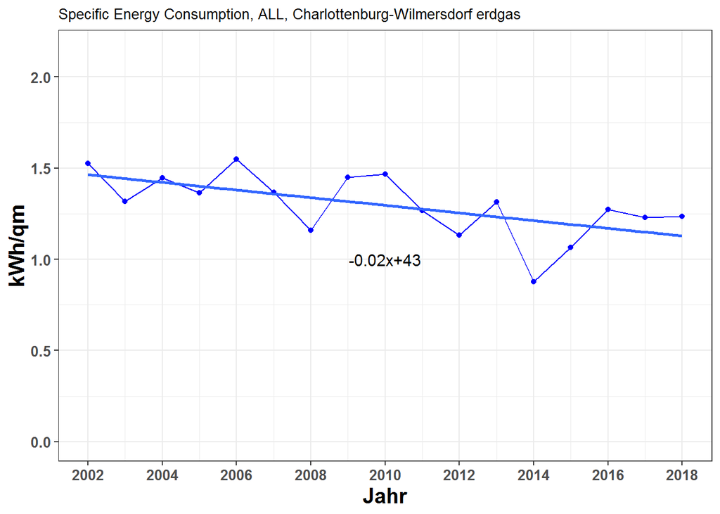

```r
g_erdgas
```

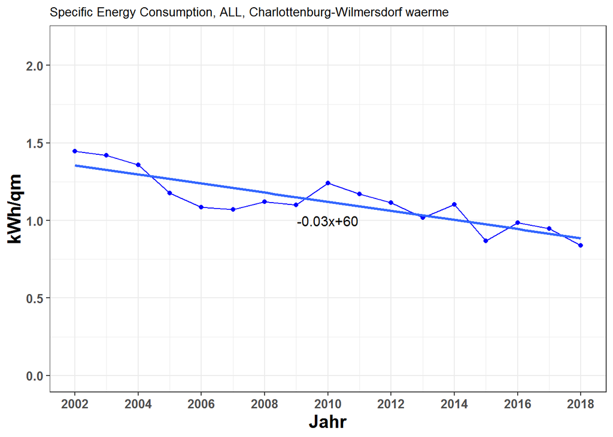

```r
g_waerme
```

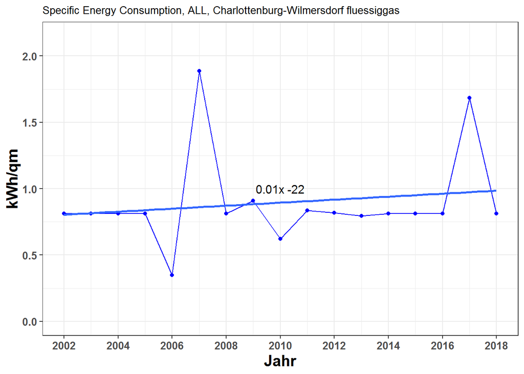

```r
g_fluessiggas
```

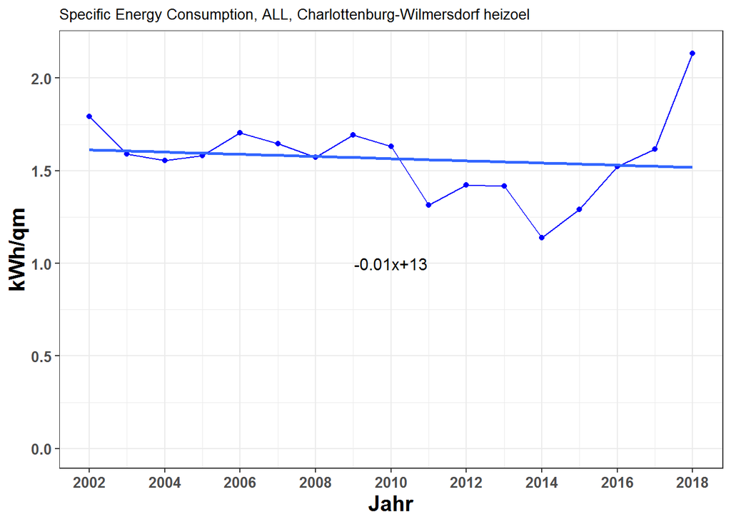

```r
g_heizoel
```